# InSituCor quick start vignette

### Installation

```r
#devtools::install_github("https://github.com/Nanostring-Biostats/InSituCor")
# setwd() in Rstudio to the InSituCor directory
# run devtools::install()
```

### Overview

The InSituCor algorithm identifies modules of “spatially co-expressed” genes - i.e. genes that tend to be expressed in the same tissue regions as each other. These modules should reveal interesting patterns in the data deserving deeper exploration.

Once spatially co-expressed modules have been detected, InSituCor provides a number of tools to help explore and interpret them.

InSituCor attempts to weed out “uninteresting” or trivial spatial correlations, for example those driven by cell type distribution. (E.g. if plasmablasts are spatially clustered, we aren’t interested in learning that IgG genes are spatially correlated, unless that correlation goes beyond what the spatial distribution of plasmablasts can explain.)

This vignette demonstrates the use of the InSituCor algorithm to find groups of spatially co-expressed genes in [CosMx](https://www.nature.com/articles/s41587-022-01483-z) data. CosMx is a spatial molecular imager for sub-cellular resolution of mRNA transcripts and protein targets. We analyze a subset of a lupus nephritis experiment.

### Preliminaries

First, we load the package and access the example data:

```r
set.seed(0)

library(InSituCor)
data(cosmx_kidney)
str(cosmx_kidney)
```

```
#> List of 3
#>  $ counts:Formal class 'dgCMatrix' [package "Matrix"] with 6 slots
#>   .. ..@ i       : int [1:23228] 6 10 13 14 27 29 42 45 49 50 ...
#>   .. ..@ p       : int [1:12] 0 1983 3536 4575 8543 11338 13834 14927 15611 16187 ...
#>   .. ..@ Dim     : int [1:2] 6555 11
#>   .. ..@ Dimnames:List of 2
#>   .. .. ..$ : chr [1:6555] "c_5_18_172" "c_5_18_174" "c_5_18_176" "c_5_18_178" ...
#>   .. .. ..$ : chr [1:11] "ITGAV" "ITGA3" "SPOCK2" "SPP1" ...
#>   .. ..@ x       : num [1:23228] 1 1 1 1 1 1 1 1 1 4 ...
#>   .. ..@ factors : list()
#>  $ annot :'data.frame':  6555 obs. of  5 variables:
#>   ..$ cell_ID    : chr [1:6555] "c_5_18_172" "c_5_18_174" "c_5_18_176" "c_5_18_178" ...
#>   ..$ fov        : int [1:6555] 18 18 18 18 18 18 18 18 18 18 ...
#>   ..$ totalcounts: num [1:6555] 530 265 170 666 364 ...
#>   ..$ negmean    : num [1:6555] 0 0.05 0 0.3 0 0.05 0 0.9 0 0.05 ...
#>   ..$ celltype   : chr [1:6555] "PCT" "Parietal.epithelium" "Connecting.tubule" "PCT" ...
#>  $ xy    : num [1:6555, 1:2] 2.7 2.63 2.12 2.61 2.87 ...
#>   ..- attr(*, "dimnames")=List of 2
#>   .. ..$ : chr [1:6555] "c_5_18_172" "c_5_18_174" "c_5_18_176" "c_5_18_178" ...
#>   .. ..$ : chr [1:2] "sdimx" "sdimy"
```

### Necessary inputs

First, let us look at the data we need.

1. A matrix of counts data, cells x genes:

```r
counts <- cosmx_kidney$counts
str(counts)
```

```
#> Formal class 'dgCMatrix' [package "Matrix"] with 6 slots
#>   ..@ i       : int [1:23228] 6 10 13 14 27 29 42 45 49 50 ...
#>   ..@ p       : int [1:12] 0 1983 3536 4575 8543 11338 13834 14927 15611 16187 ...
#>   ..@ Dim     : int [1:2] 6555 11
#>   ..@ Dimnames:List of 2
#>   .. ..$ : chr [1:6555] "c_5_18_172" "c_5_18_174" "c_5_18_176" "c_5_18_178" ...
#>   .. ..$ : chr [1:11] "ITGAV" "ITGA3" "SPOCK2" "SPP1" ...
#>   ..@ x       : num [1:23228] 1 1 1 1 1 1 1 1 1 4 ...
#>   ..@ factors : list()
```

```r
counts[1:5,1:5]
```

```
#> 5 x 5 sparse Matrix of class "dgCMatrix"
#>            ITGAV ITGA3 SPOCK2 SPP1 SAT1
#> c_5_18_172     .     .      .   15    1
#> c_5_18_174     .     .      .    2    .
#> c_5_18_176     .     .      .    .    .
#> c_5_18_178     .     .      .    6    1
#> c_5_18_179     .     .      .   10    2
```

2. A data frame containing variables we wish to condition on. These are variables that could induce uninteresting spatial correlation that would distract us from interesting results. Typically, this will include cell type (we don’t just want to discover clusters of marker genes) and technical variables like cells’ signal strength (“totalcounts”) and background level (“negmean”).

```r
# build the conditionon data frame:
annot <- cosmx_kidney$annot
rownames(annot) <- rownames(norm)
conditionon <- annot[, c("fov", "totalcounts", "negmean", "celltype")]
rownames(conditionon) <- annot$cell_ID
head(conditionon)
```

```
#>            fov totalcounts negmean            celltype
#> c_5_18_172  18         530    0.00                 PCT
#> c_5_18_174  18         265    0.05 Parietal.epithelium
#> c_5_18_176  18         170    0.00   Connecting.tubule
#> c_5_18_178  18         666    0.30                 PCT
#> c_5_18_179  18         364    0.00                 PCT
#> c_5_18_180  18         259    0.05                 PCT
```

3. xy positions, which are used to build a neighbors network. If you have multiple tissues with overlapping xy positions, then you’ll have to specify a “tissue” argument as well. Alternatively, you can provide your own neighbors network as a sparse adjacency matrix.

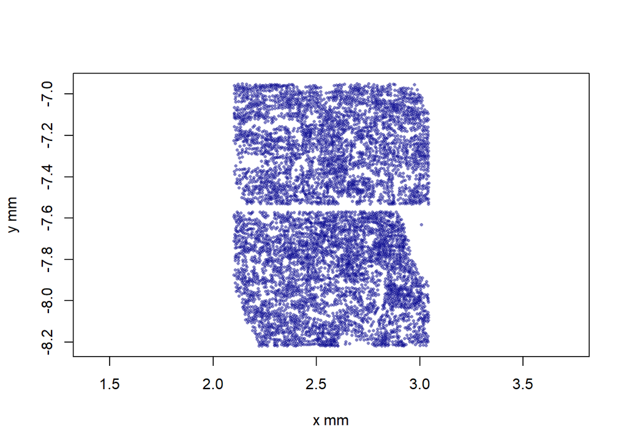

```r
xy <- cosmx_kidney$xy
plot(xy, pch = 16, cex = 0.5, col = "#00008B80",
     asp = 1, xlab = "x mm", ylab = "y mm")
```

4. Cell type assignments. InSituCor uses this information to assess the role of each cell type in each module of spatially co-expressed genes.

```r
celltype <- cosmx_kidney$annot$celltype
str(celltype)
```

```
#>  chr [1:6555] "PCT" "Parietal.epithelium" "Connecting.tubule" "PCT" "PCT" ...
```

### Running InSituCor

The complete InSituCor workflow consists of 4 steps:

- Derive a spatial correlation matrix between genes, conditioning out the influence of variables like cell type and technical effects.
- From that correlation matrix, define gene modules
- Score each cell for its module activity, and for the module activity in its neighborhood
- “Cell type attribution” analysis: quantify the role of each cell type in each module.

These steps can be run separately, or they can be run all at once using the insitucor() function. To begin, let’s run the function all at once:

```r
# normalize the counts data first:
normcounts <- sweep(counts, 1, pmax(Matrix::rowSums(counts), 1), "/")

# Call insitucor:
# Note that this tiny example dataset forced use of some non-default argument values.
# For general use, default vaues are recommended.
res <- insitucor(
               # fundamental input data:
               counts = normcounts, conditionon = conditionon, celltype = celltype,
               # args for neighbor definition:
               neighbors = NULL, xy = xy, k = 100, radius = NULL, tissue = NULL,
               # args for module definition:
               min_module_size = 2, max_module_size = 25, min_module_cor = 0.1,
               gene_weighting_rule = "inverse_sqrt",
               # args for controlling memory and compute
               roundcortozero = 0.1, max_cells = 1e5,
               # args for cell type attribution scoring
               attribution_subset_size = 1000,
               verbose = TRUE)
```

```
#> [1] "building nearest neighbors network"
#> [1] "building environment expression matrix"
#> [1] "building confounder matrix"
#> [1] "calculating conditional correlation"
#> [1] "Defining modules"
#> [1] "Calculating module scores for single cells and for cell neighborhoods"
#> [1] "Running cell type attribution analysis"
#> ITGA3_IL18_2
#> SAT1_SERPINA1_2
#> CALB1_KRT17_2
```

```r
str(res)
```

```
#> List of 6
#>  $ modules            :Classes 'data.table' and 'data.frame':    6 obs. of  3 variables:
#>   ..$ module: chr [1:6] "ITGA3_IL18_2" "ITGA3_IL18_2" "SAT1_SERPINA1_2" "SAT1_SERPINA1_2" ...
#>   ..$ gene  : chr [1:6] "ITGA3" "IL18" "SAT1" "SERPINA1" ...
#>   ..$ weight: num [1:6] 0.364 0.636 0.518 0.482 0.392 ...
#>   ..- attr(*, ".internal.selfref")=<externalptr>
#>  $ scores_env         : num [1:6555, 1:3] 0.035 0.0319 0.014 0.0273 0.0181 ...
#>   ..- attr(*, "dimnames")=List of 2
#>   .. ..$ : chr [1:6555] "c_5_18_172" "c_5_18_174" "c_5_18_176" "c_5_18_178" ...
#>   .. ..$ : chr [1:3] "ITGA3_IL18_2" "SAT1_SERPINA1_2" "CALB1_KRT17_2"
#>  $ scores_sc          : num [1:6555, 1:3] 0 0 0 0 0 ...
#>   ..- attr(*, "dimnames")=List of 2
#>   .. ..$ : chr [1:6555] "c_5_18_172" "c_5_18_174" "c_5_18_176" "c_5_18_178" ...
#>   .. ..$ : chr [1:3] "ITGA3_IL18_2" "SAT1_SERPINA1_2" "CALB1_KRT17_2"
#>  $ condcor            :Formal class 'dsCMatrix' [package "Matrix"] with 7 slots
#>   .. ..@ i       : int [1:34] 0 1 0 1 2 0 1 2 3 0 ...
#>   .. ..@ p       : int [1:12] 0 1 2 5 9 12 16 18 22 26 ...
#>   .. ..@ Dim     : int [1:2] 11 11
#>   .. ..@ Dimnames:List of 2
#>   .. .. ..$ : chr [1:11] "ITGAV" "ITGA3" "SPOCK2" "SPP1" ...
#>   .. .. ..$ : chr [1:11] "ITGAV" "ITGA3" "SPOCK2" "SPP1" ...
#>   .. ..@ x       : num [1:34] 1 1 -0.188 0.113 1 ...
#>   .. ..@ uplo    : chr "U"
#>   .. ..@ factors : list()
#>  $ attributionmats    :List of 3
#>   ..$ ITGA3_IL18_2   : num [1:26, 1:2] -0.0803 0.4646 -0.057 -0.2604 0.0428 ...
#>   .. ..- attr(*, "dimnames")=List of 2
#>   .. .. ..$ : chr [1:26] "PCT" "Parietal.epithelium" "Connecting.tubule" "Type.B.intercalated.cell" ...
#>   .. .. ..$ : chr [1:2] "ITGA3" "IL18"
#>   ..$ SAT1_SERPINA1_2: num [1:26, 1:2] 0.948 0.216 -0.265 -0.131 0.383 ...
#>   .. ..- attr(*, "dimnames")=List of 2
#>   .. .. ..$ : chr [1:26] "PCT" "Parietal.epithelium" "Connecting.tubule" "Type.B.intercalated.cell" ...
#>   .. .. ..$ : chr [1:2] "SAT1" "SERPINA1"
#>   ..$ CALB1_KRT17_2  : num [1:26, 1:2] -0.0309 0.4885 0.9752 0.6018 -0.0124 ...
#>   .. ..- attr(*, "dimnames")=List of 2
#>   .. .. ..$ : chr [1:26] "PCT" "Parietal.epithelium" "Connecting.tubule" "Type.B.intercalated.cell" ...
#>   .. .. ..$ : chr [1:2] "CALB1" "KRT17"
#>  $ celltypeinvolvement: num [1:3, 1:26] 0.0617 0.9558 -0.0309 0.4646 0.4001 ...
#>   ..- attr(*, "dimnames")=List of 2
#>   .. ..$ : chr [1:3] "ITGA3_IL18_2" "SAT1_SERPINA1_2" "CALB1_KRT17_2"
#>   .. ..$ : chr [1:26] "PCT" "Parietal.epithelium" "Connecting.tubule" "Type.B.intercalated.cell" ...
```

Our output has a number of components. First is the conditional correlation matrix:

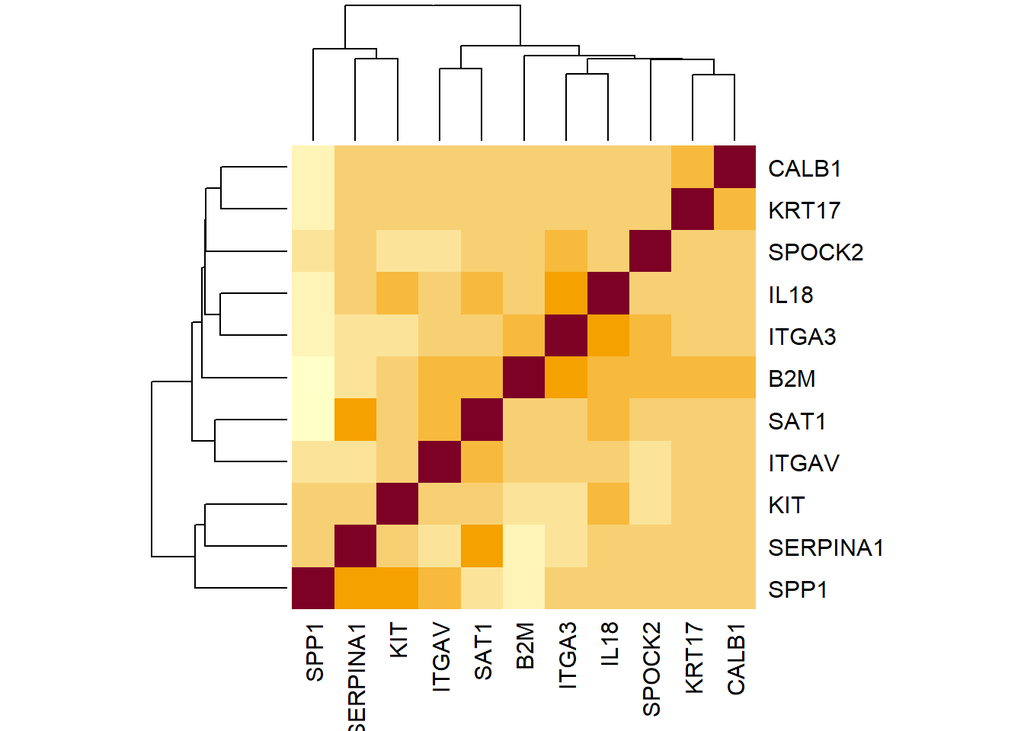

```r
heatmap(as.matrix(res$condcor))
```

Second we have the modules themselves. Each module is group of genes, with each gene given a weight:

```r
head(res$modules)
```

```
#>             module     gene    weight
#>             <char>   <char>     <num>
#> 1:    ITGA3_IL18_2    ITGA3 0.3636403
#> 2:    ITGA3_IL18_2     IL18 0.6363597
#> 3: SAT1_SERPINA1_2     SAT1 0.5178232
#> 4: SAT1_SERPINA1_2 SERPINA1 0.4821768
#> 5:   CALB1_KRT17_2    CALB1 0.3915657
#> 6:   CALB1_KRT17_2    KRT17 0.6084343
```

(In this very small dataset, relatively few genes have made their way into modules.) Modules are named using their 2-3 most influential genes, and the number of genes. E.g. a module named “ITGA3_B2M_SPOCK2_3” would be most impacted by ITGA3 and B2M, and would have 3 total genes.

Third are the per-cell module scores. Two kinds of scores are calculated: “single cell” scores, measuring module activity within a cell, and “environment” scores, measuring module activity in a cell’s environment.

```r
# single cell scores:
head(res$scores_sc)
```

```
#>            ITGA3_IL18_2 SAT1_SERPINA1_2 CALB1_KRT17_2
#> c_5_18_172            0      0.11120593    0.00000000
#> c_5_18_174            0      0.00000000    0.00000000
#> c_5_18_176            0      0.00000000    0.26104380
#> c_5_18_178            0      0.20919337    0.04345959
#> c_5_18_179            0      0.16964938    0.00000000
#> c_5_18_180            0      0.09090909    0.00000000
```

```r
# environment scores:
head(res$scores_env)
```

```
#>            ITGA3_IL18_2 SAT1_SERPINA1_2 CALB1_KRT17_2
#> c_5_18_172   0.03503932      0.12158995    0.02097408
#> c_5_18_174   0.03185602      0.11617023    0.01628499
#> c_5_18_176   0.01398323      0.10199274    0.05510462
#> c_5_18_178   0.02731062      0.10959429    0.01637960
#> c_5_18_179   0.01813808      0.11036093    0.01663089
#> c_5_18_180   0.01643541      0.08712976    0.05084598
```

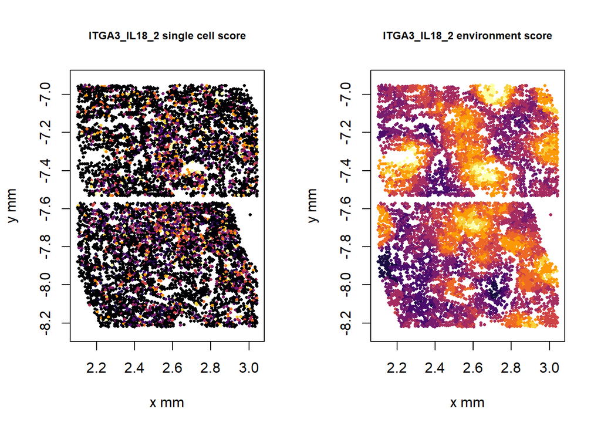

```r
# plot one module's single cell and environmnt scores:
viridiscols <- c('#000004FF', '#1B0C42FF', '#4B0C6BFF', '#781C6DFF', '#A52C60FF', '#CF4446FF', '#ED6925FF', '#FB9A06FF', '#F7D03CFF', '#FCFFA4FF')
par(mfrow = c(1, 2))
plot(xy, asp = 1, pch = 16, cex = 0.5, cex.main = 0.75,
     main = paste0(colnames(res$scores_env)[1], " single cell score"),
     xlab = "x mm", ylab = "y mm",
     col = viridiscols[1 + pmin(round(9 * (res$scores_sc[, 1] / quantile(res$scores_sc[, 1], 0.95))), 10)])
plot(xy, asp = 1, pch = 16, cex = 0.5, cex.main = 0.75,
     main = paste0(colnames(res$scores_env)[1], " environment score"),
     xlab = "x mm", ylab = "y mm",
     col = viridiscols[1 + pmin(round(9 * (res$scores_env[, 1] / quantile(res$scores_env[, 1], 0.99))), 10)])
```

Next we have details of each cell type’s involvement in each module. The big-picture view is given by the “celltypeinvolvement” result:

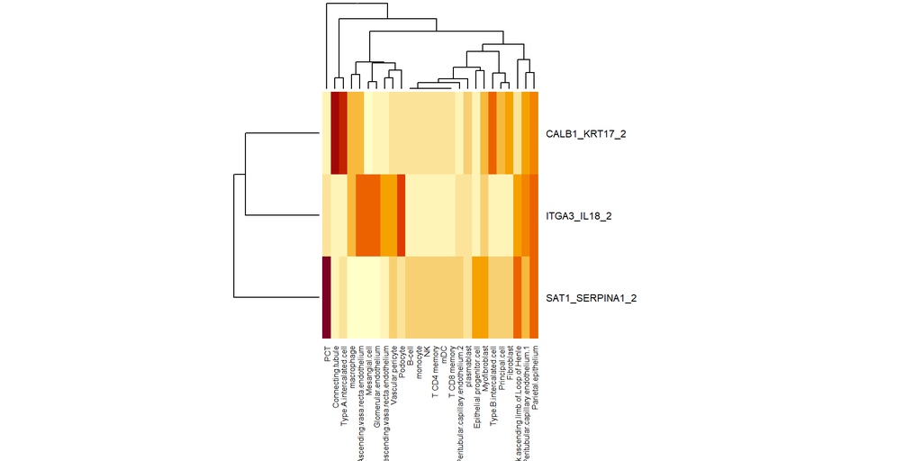

```r
heatmap(res$celltypeinvolvement, cexCol = .6, cexRow = .8, margins = c(8, 10))
```

In the above, we can see that PCT cells contribute most strongly to the “SAT1_SERPINA1_2” module, while the “ITGA3_IL18_2” module has a broader set of cell types contributing.

For more detail, we can see how each cell type contributes to each gene within a single module. The “attributionmats” result has this information:

```r
str(res$attributionmats)
```

```
#> List of 3
#>  $ ITGA3_IL18_2   : num [1:26, 1:2] -0.0803 0.4646 -0.057 -0.2604 0.0428 ...
#>   ..- attr(*, "dimnames")=List of 2
#>   .. ..$ : chr [1:26] "PCT" "Parietal.epithelium" "Connecting.tubule" "Type.B.intercalated.cell" ...
#>   .. ..$ : chr [1:2] "ITGA3" "IL18"
#>  $ SAT1_SERPINA1_2: num [1:26, 1:2] 0.948 0.216 -0.265 -0.131 0.383 ...
#>   ..- attr(*, "dimnames")=List of 2
#>   .. ..$ : chr [1:26] "PCT" "Parietal.epithelium" "Connecting.tubule" "Type.B.intercalated.cell" ...
#>   .. ..$ : chr [1:2] "SAT1" "SERPINA1"
#>  $ CALB1_KRT17_2  : num [1:26, 1:2] -0.0309 0.4885 0.9752 0.6018 -0.0124 ...
#>   ..- attr(*, "dimnames")=List of 2
#>   .. ..$ : chr [1:26] "PCT" "Parietal.epithelium" "Connecting.tubule" "Type.B.intercalated.cell" ...
#>   .. ..$ : chr [1:2] "CALB1" "KRT17"
```

```r
head(res$attributionmats[[1]])
```

```
#>                                             ITGA3        IL18
#> PCT                                   -0.08026823  0.06165709
#> Parietal.epithelium                    0.46460847  0.07145073
#> Connecting.tubule                     -0.05702393 -0.14607423
#> Type.B.intercalated.cell              -0.26044698 -0.04666188
#> Thick.ascending.limb.of.Loop.of.Henle  0.04283221  0.29798725
#> Epithelial.progenitor.cell            -0.08300033 -0.05772623
```

Here we can see that many very different cell types contribute to the genes in this module.

### Workflow for exploring InSituCor results:

Once you’ve run InSituCor, we recommend exploring your results as follows:

1. Look at module gene content to identify interesting modules. (But unless you know all the genes in the genome, expect that some interesting modules won’t attract your attention at this point.) A network diagram on the conditional correlation matrix can be a nice way to visualize your results:

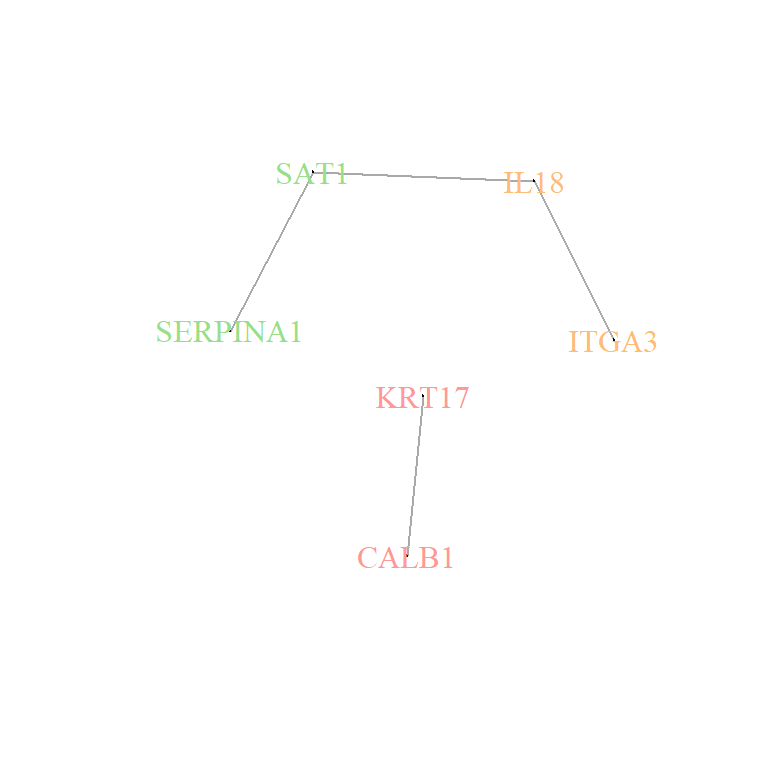

```r
plotCorrelationNetwork(res$condcor, modules = res$modules, show_gene_names = TRUE,
                       corthresh = 0.1)
```

2. Look at the output to see which modules involve the cell types you’re interested in.
3. Look at spatial maps of module environment scores to get a general feel for module behavior.

Based on steps 1-3, you’ll develop a handful of favorite modules. At this point, proceed to step 4:

4. Use your favorite interactive visualizer to plot individual transcripts from your module across space, and explore at length.

### Hands-on workflow

Advanced users wishing for more control can skip the main wrapper function and run the workflow step-by-step, evaluating results as they go.

This uses 4 functions:

- calcSpatialCor(), to compute the conditional correlation matrix
- defineModules(), to derive gene modules from this matrix
- scoreModules(), to score cells for module activity at the single-cell and environment level
- cellTypeAttribution(), to evaluate the role of each cell type in each module

Below is an example workflow using these modules:

```r
# get conditional correlation, deriving a neighbor network and an "environment matrix" along the way:
step1 <- calcSpatialCor(counts = normcounts,
                      conditionon = annot[, c("fov", "totalcounts", "negmean", "celltype")],
                      neighbors = NULL,
                      xy = xy,
                      k = 50,
                      radius = NULL,
                      tissue = annot$fov, # example of using tissue in neighbor definition
                      roundcortozero = 0.1,
                      max_cells = 1e5,
                      verbose = FALSE)
str(step1)
```

```
#> List of 3
#>  $ condcor  :Formal class 'dsCMatrix' [package "Matrix"] with 7 slots
#>   .. ..@ i       : int [1:30] 0 1 0 1 2 0 1 2 3 0 ...
#>   .. ..@ p       : int [1:12] 0 1 2 5 9 12 16 18 20 22 ...
#>   .. ..@ Dim     : int [1:2] 11 11
#>   .. ..@ Dimnames:List of 2
#>   .. .. ..$ : chr [1:11] "ITGAV" "ITGA3" "SPOCK2" "SPP1" ...
#>   .. .. ..$ : chr [1:11] "ITGAV" "ITGA3" "SPOCK2" "SPP1" ...
#>   .. ..@ x       : num [1:30] 1 1 -0.115 0.11 1 ...
#>   .. ..@ uplo    : chr "U"
#>   .. ..@ factors : list()
#>  $ env      : num [1:6555, 1:11] 0.027 0.0242 0.0367 0.0228 0.0323 ...
#>   ..- attr(*, "dimnames")=List of 2
#>   .. ..$ : chr [1:6555] "c_5_18_172" "c_5_18_174" "c_5_18_176" "c_5_18_178" ...
#>   .. ..$ : chr [1:11] "ITGAV" "ITGA3" "SPOCK2" "SPP1" ...
#>  $ neighbors:Formal class 'dgCMatrix' [package "Matrix"] with 6 slots
#>   .. ..@ i       : int [1:327750] 1 22 30 40 54 59 62 63 73 78 ...
#>   .. ..@ p       : int [1:6556] 0 29 60 89 114 141 181 207 239 276 ...
#>   .. ..@ Dim     : int [1:2] 6555 6555
#>   .. ..@ Dimnames:List of 2
#>   .. .. ..$ : chr [1:6555] "c_5_18_172" "c_5_18_174" "c_5_18_176" "c_5_18_178" ...
#>   .. .. ..$ : chr [1:6555] "c_5_18_172" "c_5_18_174" "c_5_18_176" "c_5_18_178" ...
#>   .. ..@ x       : num [1:327750] 0.0603 0.0405 0.0135 0.0379 0.0179 ...
#>   .. ..@ factors : list()
```

```r
# derive Modules
modules <- defineModules(condcor = step1$condcor,
                            env = step1$env,
                            min_module_size = 2,
                            max_module_size = 20,
                            resolution = 0.005,
                            gene_weighting_rule = "inverse_sqrt")
str(modules)
```

```
#> List of 3
#>  $ modules  :List of 2
#>   ..$ ITGA3_SPOCK2_2: chr [1:2] "ITGA3" "SPOCK2"
#>   ..$ CALB1_KRT17_2 : chr [1:2] "CALB1" "KRT17"
#>  $ weights  :List of 2
#>   ..$ ITGA3_SPOCK2_2: Named num [1:2] 0.465 0.535
#>   .. ..- attr(*, "names")= chr [1:2] "ITGA3" "SPOCK2"
#>   ..$ CALB1_KRT17_2 : Named num [1:2] 0.389 0.611
#>   .. ..- attr(*, "names")= chr [1:2] "CALB1" "KRT17"
#>  $ weightsdf:Classes 'data.table' and 'data.frame':  4 obs. of  3 variables:
#>   ..$ module: chr [1:4] "ITGA3_SPOCK2_2" "ITGA3_SPOCK2_2" "CALB1_KRT17_2" "CALB1_KRT17_2"
#>   ..$ gene  : chr [1:4] "ITGA3" "SPOCK2" "CALB1" "KRT17"
#>   ..$ weight: num [1:4] 0.465 0.535 0.389 0.611
#>   ..- attr(*, ".internal.selfref")=<externalptr>
```

```r
# score cells for module activity:
scores <- scoreModules(counts = normcounts,
                       weights = modules$weights,
                       neighbors = step1$neighbors)
str(scores)
```

```
#> List of 2
#>  $ scores_env: num [1:6555, 1:2] 0.01798 0.01159 0.01207 0.00729 0.01703 ...
#>   ..- attr(*, "dimnames")=List of 2
#>   .. ..$ : chr [1:6555] "c_5_18_172" "c_5_18_174" "c_5_18_176" "c_5_18_178" ...
#>   .. ..$ : chr [1:2] "ITGA3_SPOCK2_2" "CALB1_KRT17_2"
#>  $ scores_sc : num [1:6555, 1:2] 0 0 0 0 0 0 0 0 0 0 ...
#>   ..- attr(*, "dimnames")=List of 2
#>   .. ..$ : chr [1:6555] "c_5_18_172" "c_5_18_174" "c_5_18_176" "c_5_18_178" ...
#>   .. ..$ : chr [1:2] "ITGA3_SPOCK2_2" "CALB1_KRT17_2"
```

```r
# score cell type involvement:
attribution <- cellTypeAttribution(
  modulescores = scores$scores_env,
  weights = modules$weights,
  counts = normcounts,
  celltype = annot$celltype,
  neighbors = step1$neighbors,
  nsub = 1000,
  verbose = TRUE)
```

```
#> ITGA3_SPOCK2_2
#> CALB1_KRT17_2
```

```r
str(attribution)
```

```
#> List of 2
#>  $ involvescores  : num [1:2, 1:26] -0.1918 -0.0139 0.596 0.4612 -0.103 ...
#>   ..- attr(*, "dimnames")=List of 2
#>   .. ..$ : chr [1:2] "ITGA3_SPOCK2_2" "CALB1_KRT17_2"
#>   .. ..$ : chr [1:26] "PCT" "Parietal.epithelium" "Connecting.tubule" "Type.B.intercalated.cell" ...
#>  $ attributionmats:List of 2
#>   ..$ ITGA3_SPOCK2_2: num [1:26, 1:2] -0.254 0.596 -0.103 -0.14 -0.11 ...
#>   .. ..- attr(*, "dimnames")=List of 2
#>   .. .. ..$ : chr [1:26] "PCT" "Parietal.epithelium" "Connecting.tubule" "Type.B.intercalated.cell" ...
#>   .. .. ..$ : chr [1:2] "ITGA3" "SPOCK2"
#>   ..$ CALB1_KRT17_2 : num [1:26, 1:2] -0.0139 0.4612 0.9635 0.5474 -0.062 ...
#>   .. ..- attr(*, "dimnames")=List of 2
#>   .. .. ..$ : chr [1:26] "PCT" "Parietal.epithelium" "Connecting.tubule" "Type.B.intercalated.cell" ...
#>   .. .. ..$ : chr [1:2] "CALB1" "KRT17"
```